# assignment_2 exhibits

Hugo TING

2022-11-25

# data summary

Data Summary

|  | mean | SD | min | max | median | p95 | N |
| --- | --- | --- | --- | --- | --- | --- | --- |
| high_rated | 0.74 | 0.44 | 0.00 | 1.00 | 1.00 | 1.00 | 895 |
| distance | 0.87 | 0.99 | 0.00 | 4.80 | 0.60 | 3.70 | 895 |
| stars | 3.33 | 1.00 | 1.00 | 5.00 | 4.00 | 5.00 | 895 |
| lnprice | 4.94 | 0.57 | 3.83 | 6.39 | 4.88 | 6.02 | 895 |

# Plots for distance/stars vs probability of being high rated

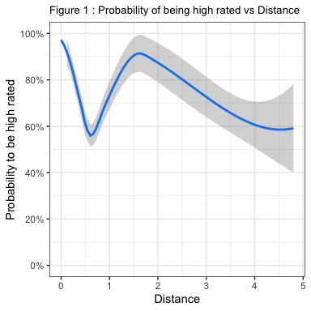

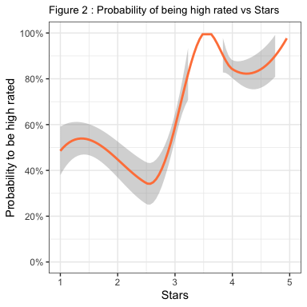

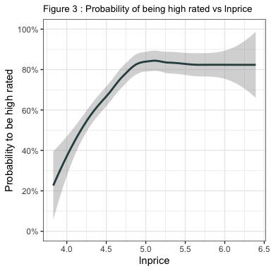

# we used logit regression because it restrict the probability values between zero and 1 (include in documentation)

# Regression Model Summary

Regression Model Summary of Hotels in Seville

1. LPM
2. logit coeffs
3. logit marg
4. probit
5. probit marg

Constant

0.277*

−1.035

−1.035

−0.666

−0.666

(0.139)

(0.874)

(0.874)

(0.510)

(0.510)

4 stars or lower

0.098**

0.526**

0.083**

0.326**

0.087**

0.083**

0.326**

0.326**

0.098**

0.526**

0.526**

0.326**

0.087**

0.098**

0.526**

0.526**

0.326**

0.326**

(0.016)

(0.093)

(0.016)

(0.055)

(0.014)

(0.016)

(0.093)

(0.016)

(0.055)

(0.055)

(0.016)

(0.093)

(0.093)

(0.055)

(0.014)

(0.016)

(0.093)

(0.093)

(0.055)

(0.055)

higher than 4 stars

0.096

15.455

0.266**

4.291

0.265**

0.266**

4.291

4.291

0.096

15.455

15.455

4.291

0.265**

0.096

15.455

15.455

4.291

4.291

(0.063)

(554.745)

(0.014)

(83.662)

(0.014)

(0.063)

(554.745)

(0.014)

(83.662)

(83.662)

(0.063)

(554.745)

(554.745)

(83.662)

(0.014)

(0.063)

(554.745)

(554.745)

(83.662)

(83.662)

disatnce >= 0.6

−0.697**

−4.658**

−0.730**

−2.693**

−0.715**

−0.730**

−2.693**

−2.693**

−0.697**

−4.658**

−4.658**

−2.693**

−0.715**

−0.697**

−4.658**

−4.658**

−2.693**

−2.693**

(0.082)

(0.610)

(0.113)

(0.338)

(0.081)

(0.082)

(0.610)

(0.113)

(0.338)

(0.338)

(0.082)

(0.610)

(0.610)

(0.338)

(0.081)

(0.082)

(0.610)

(0.610)

(0.338)

(0.338)

disatnce >0.6, <=1.6

0.278**

1.529**

0.240**

0.896**

0.238**

0.240**

0.896**

0.896**

0.278**

1.529**

1.529**

0.896**

0.238**

0.278**

1.529**

1.529**

0.896**

0.896**

(0.058)

(0.382)

(0.063)

(0.220)

(0.057)

(0.058)

(0.382)

(0.063)

(0.220)

(0.220)

(0.058)

(0.382)

(0.382)

(0.220)

(0.057)

(0.058)

(0.382)

(0.382)

(0.220)

(0.220)

disatnce >1.6

−0.102**

−0.503**

−0.079**

−0.309**

−0.082**

−0.079**

−0.309**

−0.309**

−0.102**

−0.503**

−0.503**

−0.309**

−0.082**

−0.102**

−0.503**

−0.503**

−0.309**

−0.309**

(0.031)

(0.184)

(0.030)

(0.109)

(0.028)

(0.031)

(0.184)

(0.030)

(0.109)

(0.109)

(0.031)

(0.184)

(0.184)

(0.109)

(0.028)

(0.031)

(0.184)

(0.184)

(0.109)

(0.109)

lnprice

0.081**

0.480**

0.075**

0.282**

0.075**

0.075**

0.282**

0.282**

0.081**

0.480**

0.480**

0.282**

0.075**

0.081**

0.480**

0.480**

0.282**

0.282**

(0.027)

(0.168)

(0.027)

(0.098)

(0.026)

(0.027)

(0.168)

(0.027)

(0.098)

(0.098)

(0.027)

(0.168)

(0.168)

(0.098)

(0.026)

(0.027)

(0.168)

(0.168)

(0.098)

(0.098)

Num.Obs.

895

895

895

895

895

RMSE

0.40

0.40

0.40

0.40

0.40

* p < 0.05, ** p < 0.01

# Predicted Probability of LPM, Logit and Probit Models

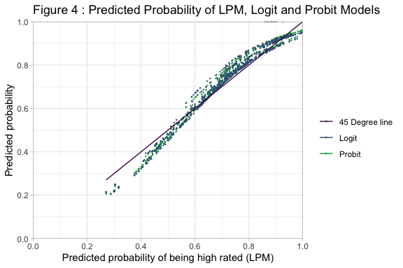